# Red Wine Analysis

Gayerike Guha Thakurata

28 March 2018

## 1. Project Objective

The main objective of this project is to analyze the Red Wine Data and try to understand which variables are affecting the quality of the red wine. First we need to do the inter-variable analysis i.e. find out the correlation between the variables and the Red Wine Quality along with other factors thrown in. Finally we will create a linear model to predict the outcome.

### ——————————————————————————————————————

### ——————————————————————————————————————

## 2. Data Set Insight

### Structure of the Dataframe

```
## 'data.frame':    1599 obs. of  14 variables:
##  $ X                   : int  1 2 3 4 5 6 7 8 9 10 ...
##  $ fixed.acidity       : num  7.4 7.8 7.8 11.2 7.4 7.4 7.9 7.3 7.8 7.5 ...
##  $ volatile.acidity    : num  0.7 0.88 0.76 0.28 0.7 0.66 0.6 0.65 0.58 0.5 ...
##  $ citric.acid         : num  0 0 0.04 0.56 0 0 0.06 0 0.02 0.36 ...
##  $ residual.sugar      : num  1.9 2.6 2.3 1.9 1.9 1.8 1.6 1.2 2 6.1 ...
##  $ chlorides           : num  0.076 0.098 0.092 0.075 0.076 0.075 0.069 0.065 0.073 0.071 ...
##  $ free.sulfur.dioxide : num  11 25 15 17 11 13 15 15 9 17 ...
##  $ total.sulfur.dioxide: num  34 67 54 60 34 40 59 21 18 102 ...
##  $ density             : num  0.998 0.997 0.997 0.998 0.998 ...
##  $ pH                  : num  3.51 3.2 3.26 3.16 3.51 3.51 3.3 3.39 3.36 3.35 ...
##  $ sulphates           : num  0.56 0.68 0.65 0.58 0.56 0.56 0.46 0.47 0.57 0.8 ...
##  $ alcohol             : num  9.4 9.8 9.8 9.8 9.4 9.4 9.4 10 9.5 10.5 ...
##  $ quality             : Ord.factor w/ 6 levels "3"<"4"<"5"<"6"<..: 3 3 3 4 3 3 3 5 5 3 ...
##  $ ratedQuality        : Ord.factor w/ 3 levels "bad"<"average"<..: 2 2 2 2 2 2 2 3 3 2 ...
```

### Summary of the dataframe

```
##        X          fixed.acidity   volatile.acidity  citric.acid
##  Min.   :   1.0   Min.   : 4.60   Min.   :0.1200   Min.   :0.000
##  1st Qu.: 400.5   1st Qu.: 7.10   1st Qu.:0.3900   1st Qu.:0.090
##  Median : 800.0   Median : 7.90   Median :0.5200   Median :0.260
##  Mean   : 800.0   Mean   : 8.32   Mean   :0.5278   Mean   :0.271
##  3rd Qu.:1199.5   3rd Qu.: 9.20   3rd Qu.:0.6400   3rd Qu.:0.420
##  Max.   :1599.0   Max.   :15.90   Max.   :1.5800   Max.   :1.000
##  residual.sugar     chlorides       free.sulfur.dioxide
##  Min.   : 0.900   Min.   :0.01200   Min.   : 1.00
##  1st Qu.: 1.900   1st Qu.:0.07000   1st Qu.: 7.00
##  Median : 2.200   Median :0.07900   Median :14.00
##  Mean   : 2.539   Mean   :0.08747   Mean   :15.87
##  3rd Qu.: 2.600   3rd Qu.:0.09000   3rd Qu.:21.00
##  Max.   :15.500   Max.   :0.61100   Max.   :72.00
##  total.sulfur.dioxide    density             pH          sulphates
##  Min.   :  6.00       Min.   :0.9901   Min.   :2.740   Min.   :0.3300
##  1st Qu.: 22.00       1st Qu.:0.9956   1st Qu.:3.210   1st Qu.:0.5500
##  Median : 38.00       Median :0.9968   Median :3.310   Median :0.6200
##  Mean   : 46.47       Mean   :0.9967   Mean   :3.311   Mean   :0.6581
##  3rd Qu.: 62.00       3rd Qu.:0.9978   3rd Qu.:3.400   3rd Qu.:0.7300
##  Max.   :289.00       Max.   :1.0037   Max.   :4.010   Max.   :2.0000
##     alcohol      quality  ratedQuality
##  Min.   : 8.40   3: 10   bad    :  63
##  1st Qu.: 9.50   4: 53   average:1319
##  Median :10.20   5:681   good   : 217
##  Mean   :10.42   6:638
##  3rd Qu.:11.10   7:199
##  Max.   :14.90   8: 18
```

### ——————————————————————————————————————

### ——————————————————————————————————————

## 3. Univariate Plots

We need to understand the relation of independent variables to our output. The correlation between them, skewness, shape of distribution- either normal or not. Moreover the present of outliers will also affect our analysis. Hence we need to remove those outliers for building our model. This will give us an idea about how to proceed on further analysis.

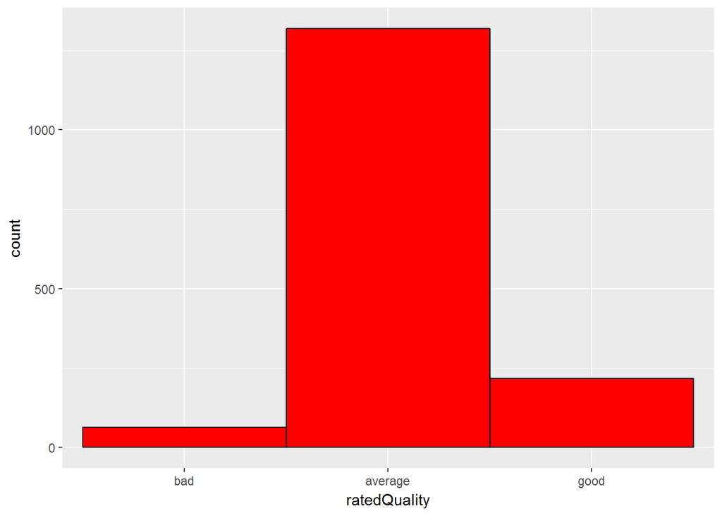

### Inference:

From these plots we can conclude that most of the wine quality are ‘average’. There seems to be some issue with data collection. The data does not seem to be accurate. The data might have been collected from a specific region/town/area. The good quality and the poor quality wines are almost like outliers here, it might be difficult to get an accurate model of the Wine Quality.

### 1. Analysing Fixed Acidity

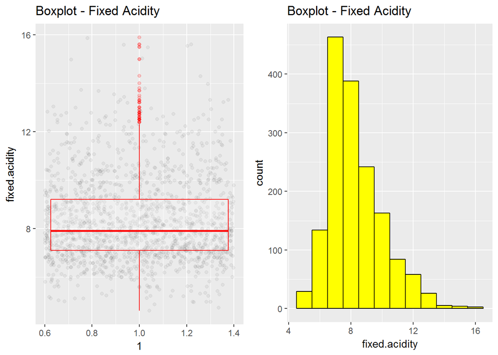

### 2. Analysing Volatile Acidity

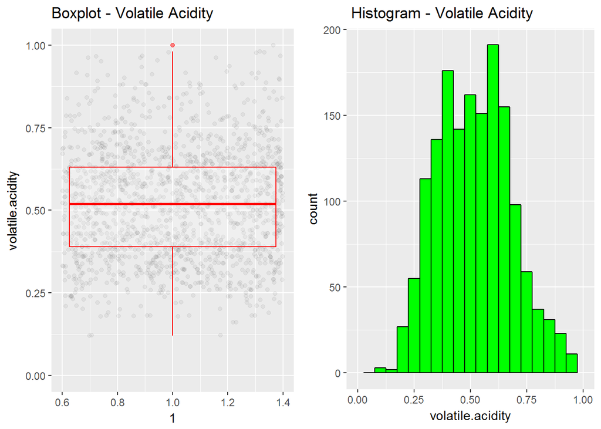

Here the distribution seems to be bimodal. There are two peaks around 0.4 and 0.6.

### 3. Analysing Citric Acid

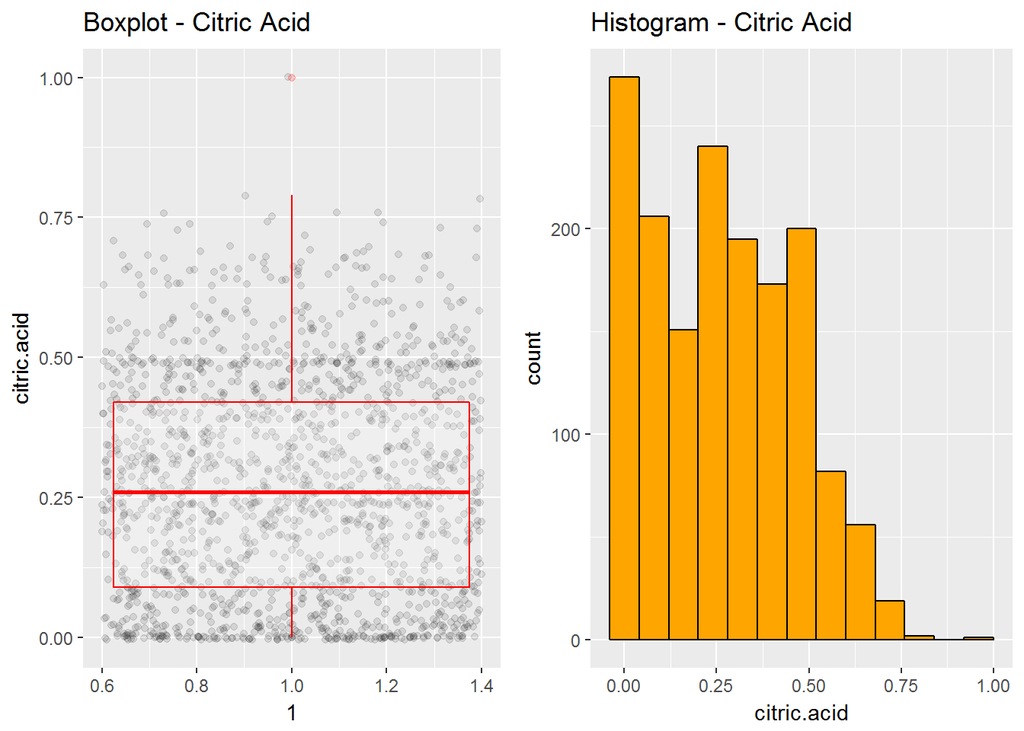

The median here is around 0.25. But that might be because of outliers present. Apart from some outliers, the distribution of Citric acid looks like bimodal.

### 4. Analysing Residual Sugar

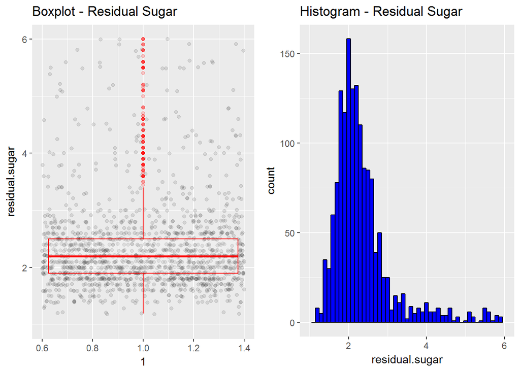

This distribution is heaviy skewed with peaks around 2-2.7 and also there are many outliers present.

### 5. Analysing Chlorides

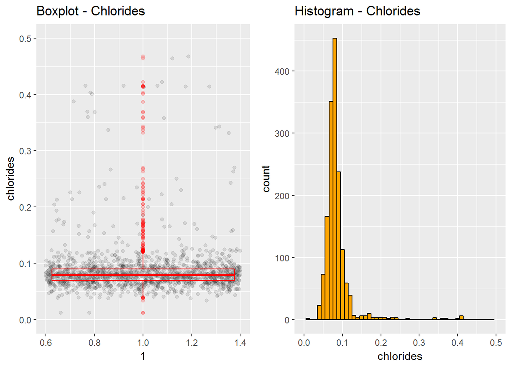

### 6. Analysing Free Sulphur Dioxide

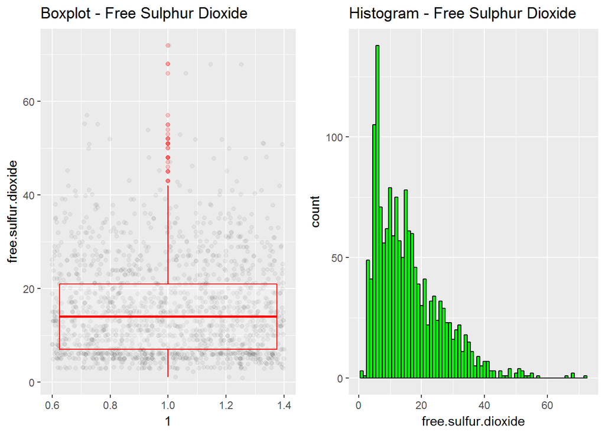

For Free Sulphur Dioxide, there are some outliers in the high range. The distribution is positively skewed with long tailed patterns.

### 7. Analysing Total Sulphur Dioxide

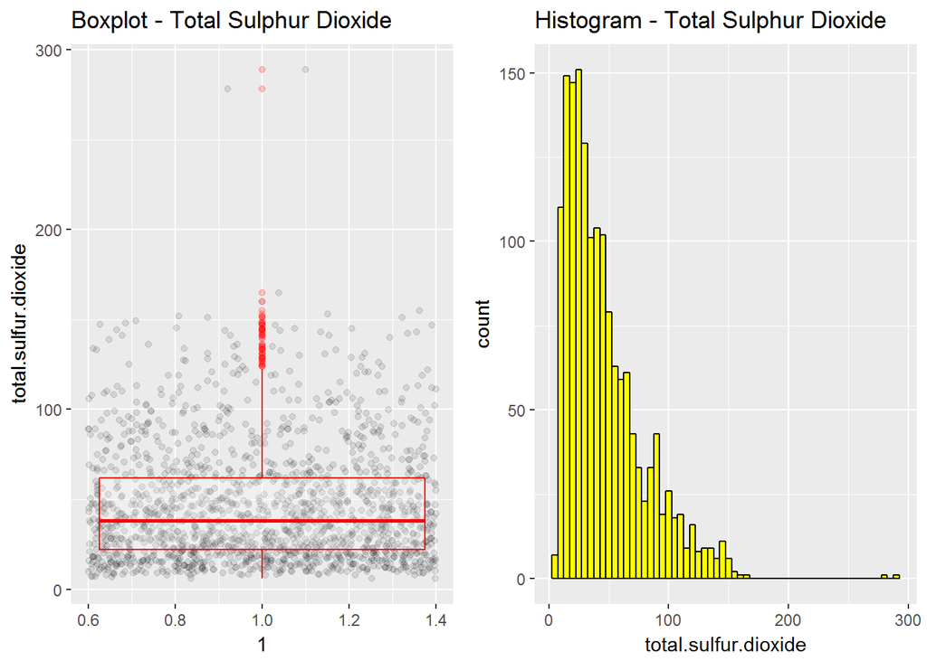

Being a sub-category of the previous variable, Total Sulphur Dioxide also follows a similar pattern.

### 8. Analysing Density

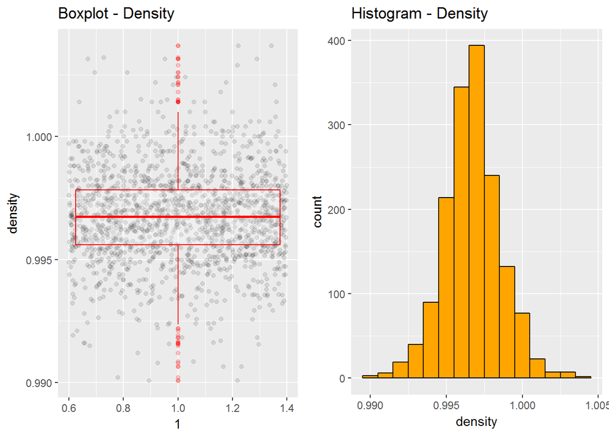

This Variable has almost a perfect Normal Distribution.

### 9. Analysing pH

[figure not shown]

pH also has a very Normally distributed shape.

### 10. Analysing Sulphates

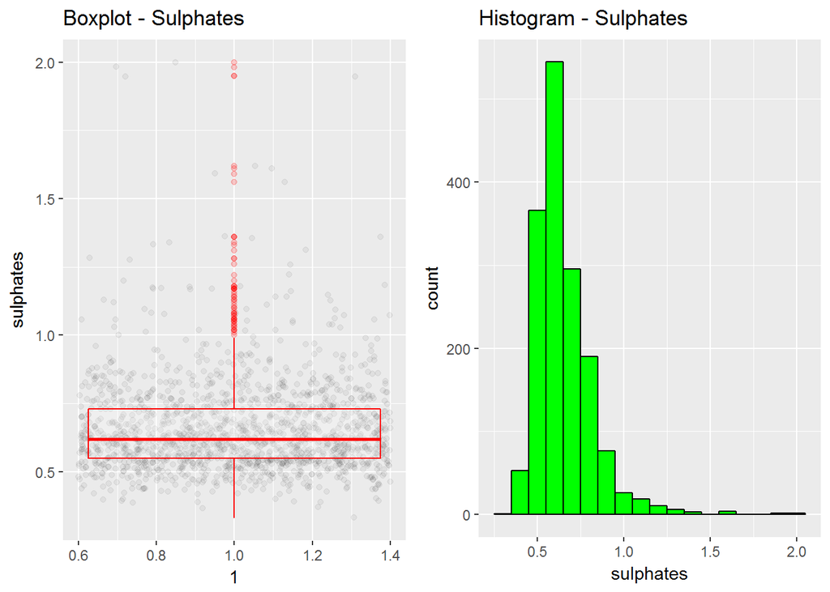

Sulphates also exhibit a similar long tailed distribution like Chlorides or Free/Total Sulphur Dioxide. It has relatively less outliers.

### 11. Analysing Alcohol

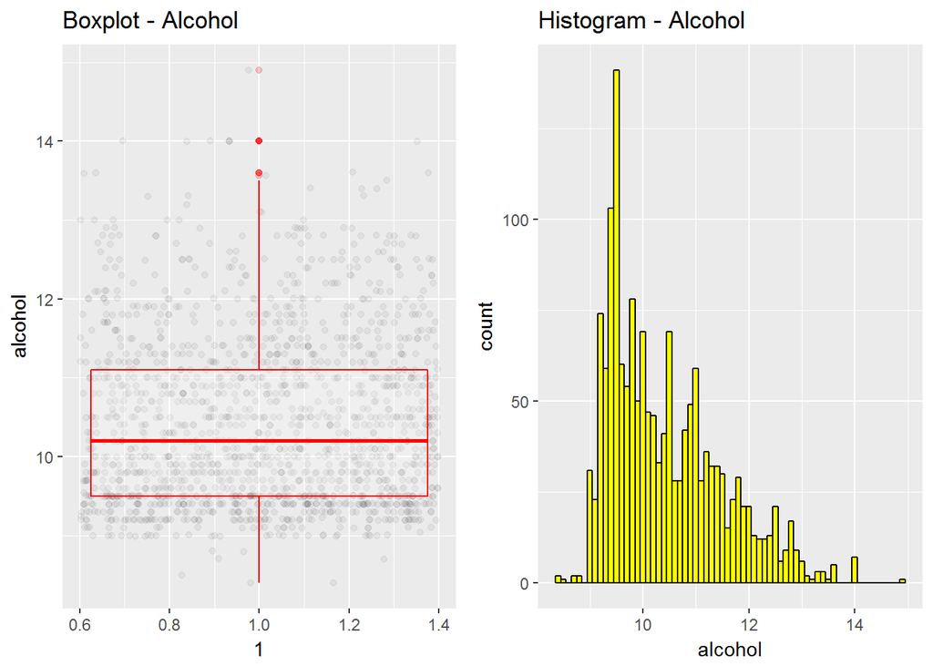

Alcohol also exhibits a right skewed distribution. But these are more heavily skewed distributon than others.

### ——————————————————————————————————————

### ——————————————————————————————————————

## 4. Analysis of the Univariate Plots

### 1. Our Objective

Our Objective to find out the quality of wine. Hence our main focus to determine the independent variables which contributes to wine quality.

### 2. Inference

PH is an important factor in determining the wine quality. This is because General chemistry says PH is related to acidity and hence may have some effect on the quality. Also ph level might be affected by the different acids present in the wine and if this is the case then the overall pH will definitely affect the quality of the wine. We also cannot ignore residual sugar. The residual sugar will have an effect on the wine quality as sugar determines the sweetness of the wine and hence might adversely affect the taste of the wine.

### 3. Plot Distributions and Characteristics

1. Density and pH seems normally distributed with few outliers.
2. Residual sugar and Chloride seems to have extreme outliers.
3. Fixed and volatile acidity, total and free sulfur dioxides,  
   alcohol and sulphates seem to be long-tailed for the outliers present.
4. Citric acid has large number of zero values.

### ——————————————————————————————————————

### ——————————————————————————————————————

## 5. Bivariate Plots

Now we need to focus on collinearity between variables. Collinearity is the property which depicts interdependency between variables. The correlation cofficient between 2 variables will give us an idea how different variables are correlated to one another.

### 1. Scatter plot matrix along with Correlation Coefficients

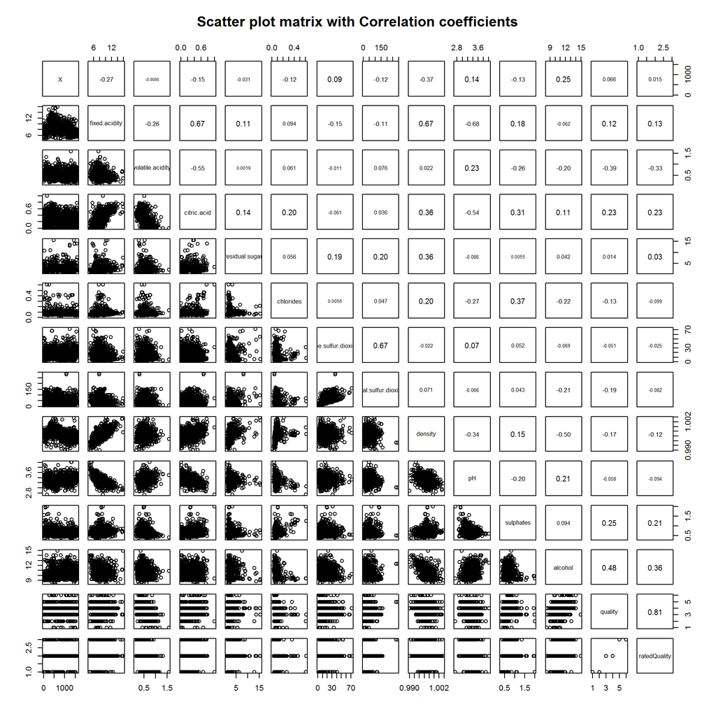

From the above plot we can find out that: 1. Density has a very strong correlation with Fixed Acidity.

2. Volatile acidity has a positive correlation with pH. But normal chemistry defy this rule. So we need to look deep into it
3. The variables most strongly correlated to quality are Volatile Acidity and Alcohol.
4. Alcohol has negative correlation with density. This is evident from the fact that the density of water is greater than the density of alcohol.

Now we will look into different plots and find out out how different parameters are related to wine Quality

### 2. Analysing Quality vs Fixed Acidity

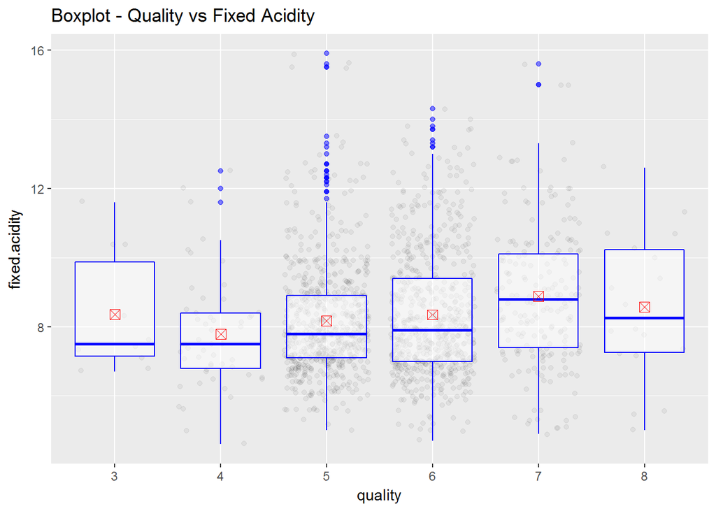

We can easily conclude that Fixed Acidity has almost no effect on the Quality. The mean and median values of fixed acidity remains almost unchanged with increase in quality.

### 3. Analysing Quality vs Volatile Acidity

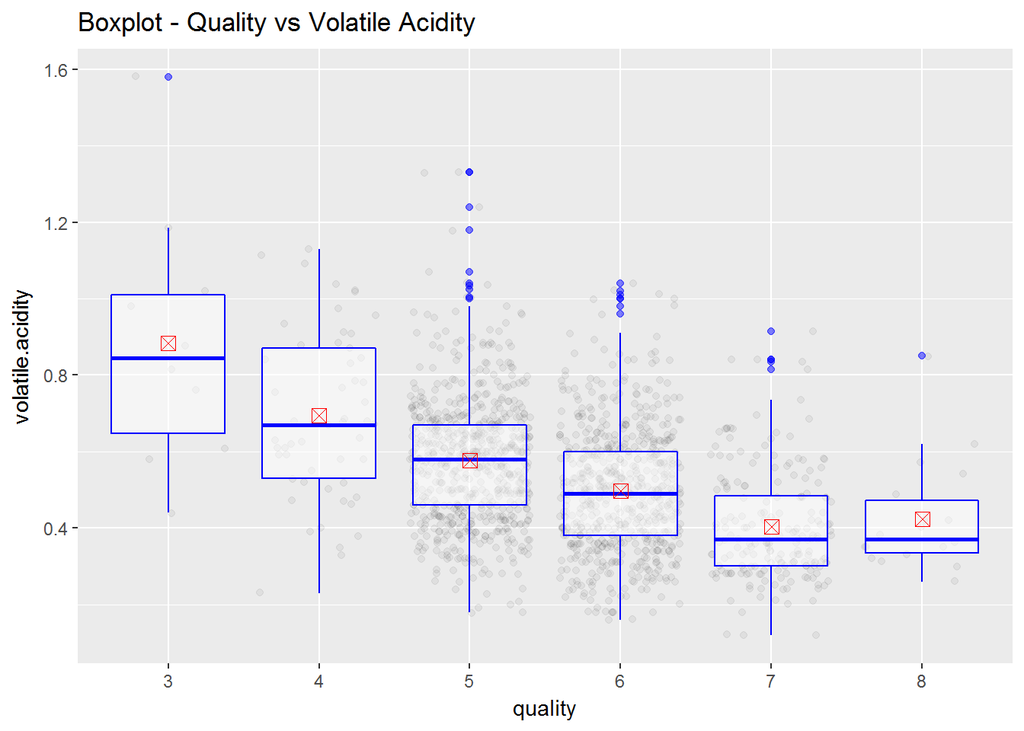

Volatile acid seems to have a negative impact on the quality of the wine. As volatile acid level increases, the quality of the wine degrades.

### 4. Analysing Quality vs Citric Acid

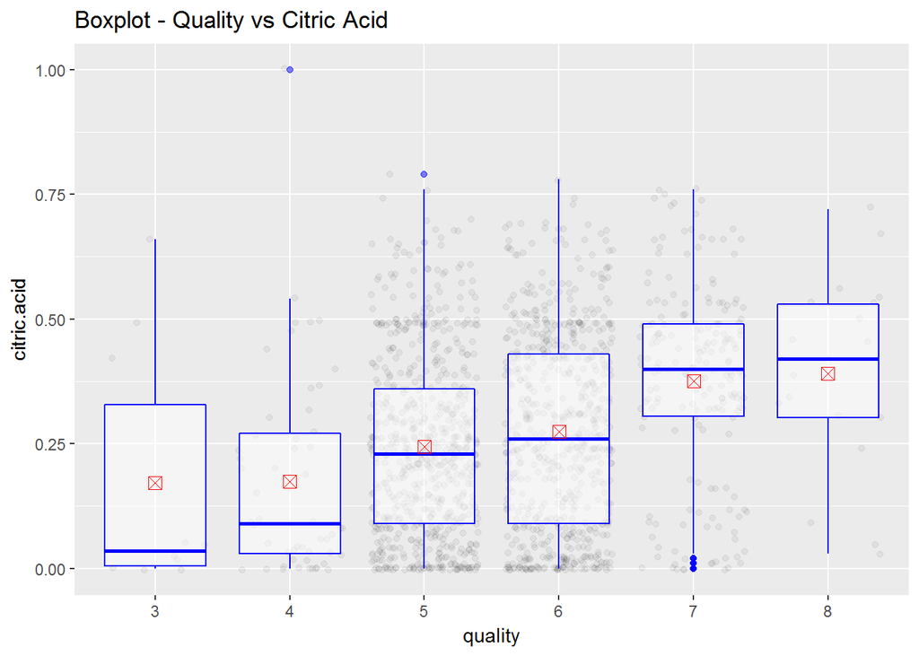

Citric acid seems to have a positive correlation with Wine Quality.

### 5. Analysing Quality vs Residual Sugar

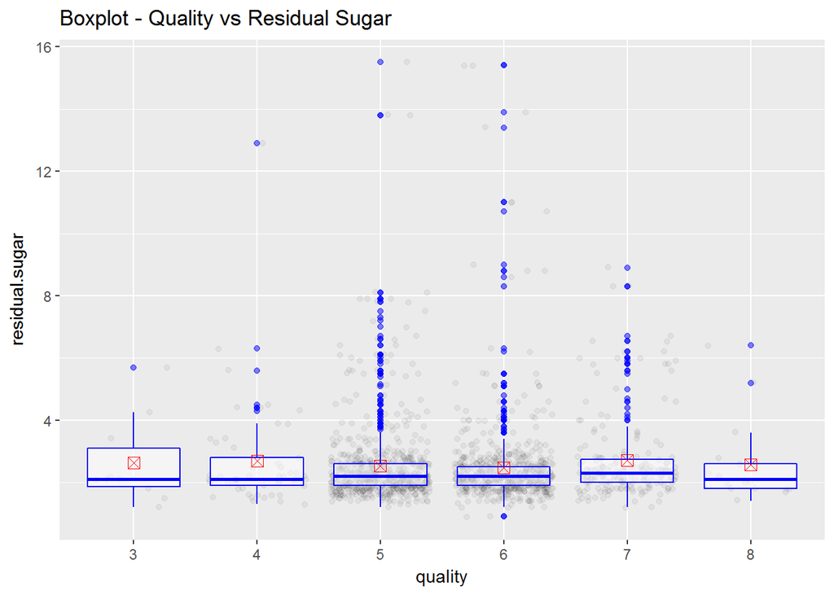

This plot contradicts our last assumption and shows that Residual Sugar almost has no effect on the Quality of the Wine. The mean values for the residual sugar is almost the same for every quality of wine.

### 6. Analysing Quality vs Chlorides

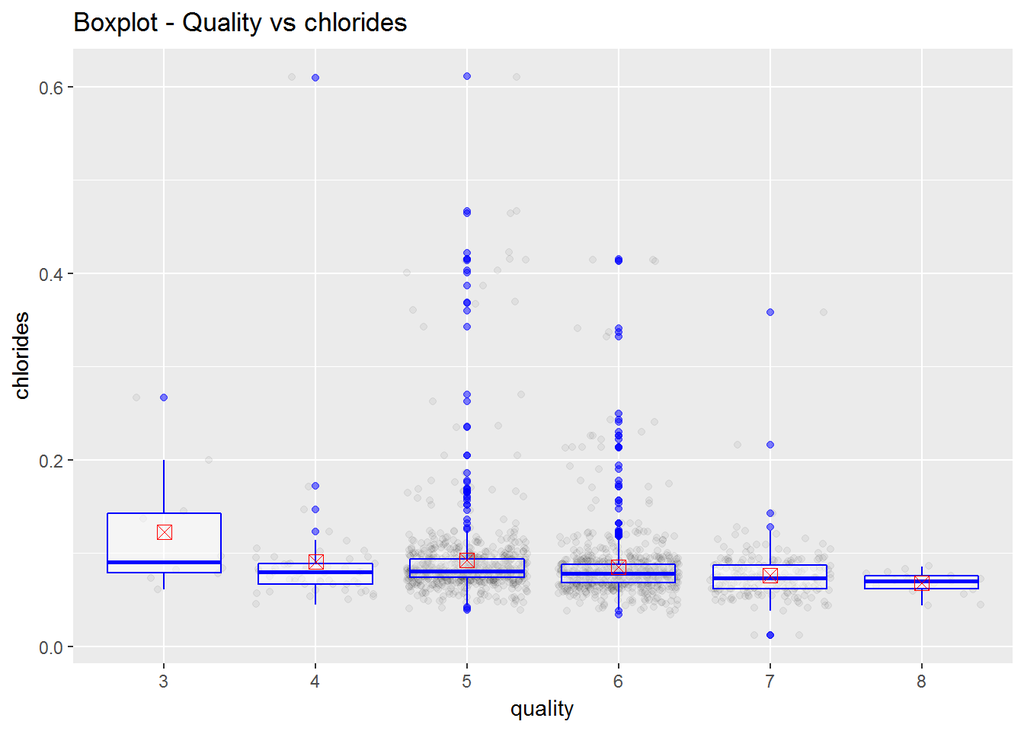

Chlorides as weak correlation to quality. It is very negligible though.

### 7. Analysing Quality vs Free Sulfur Dioxide

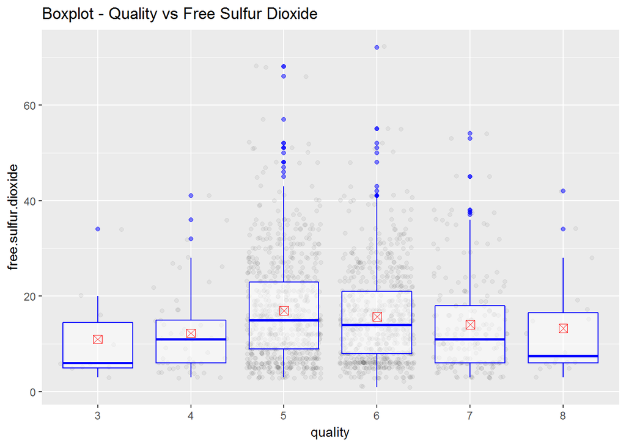

We see that too low concentration of Free Sulphur Dioxide produces poor wine and too high concentration results in average wine.

### 8. Analysing Quality vs Total Sulfur Dioxide

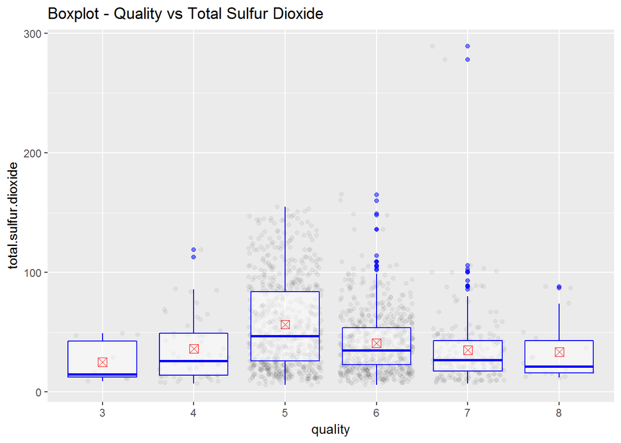

As this is a sub-category of Free Sulphur Dioxide, we see a similar pattern here.

### 9. Analysing Quality vs Density

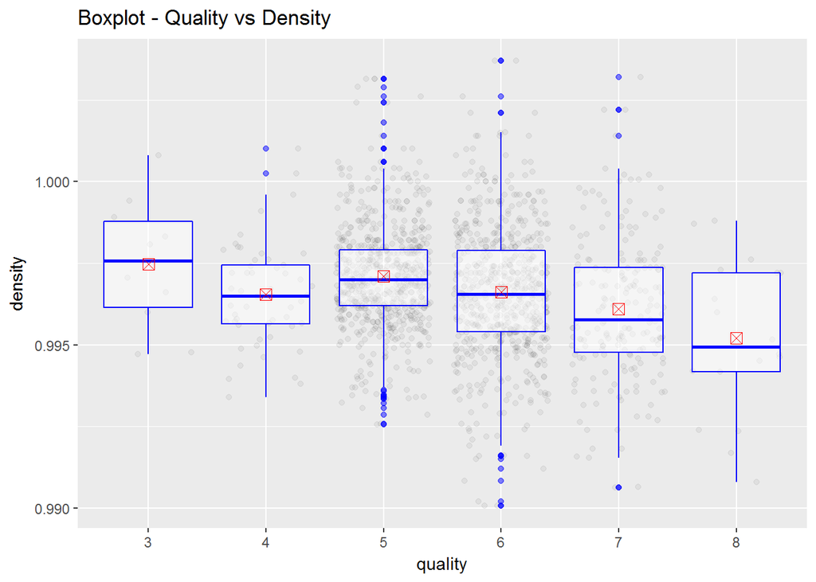

Better wines seems to have lower densities. But may be it will be wise not to draw any conclusions here. Because there might be a possibility that the low density is due to higher alcohol content which actually is the driving factor for better wines.

### 10. Analysing Quality vs PH

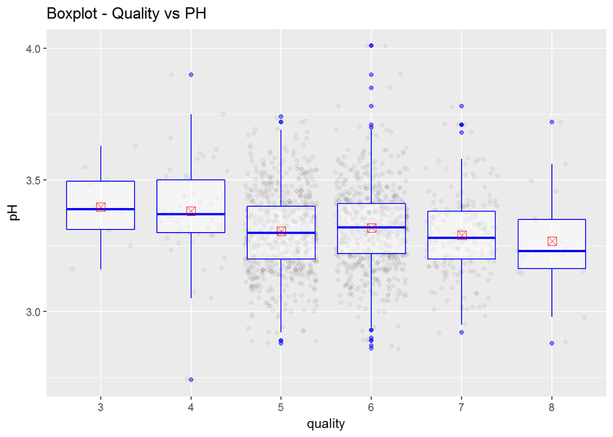

Better wines seems to have less pH, i.e they are more acidic. There are a quite a few outliers in this observation.

So we need to analyse how the individual variables are affected by PH.

### 11. Analysing PH vs Fixed Acidity

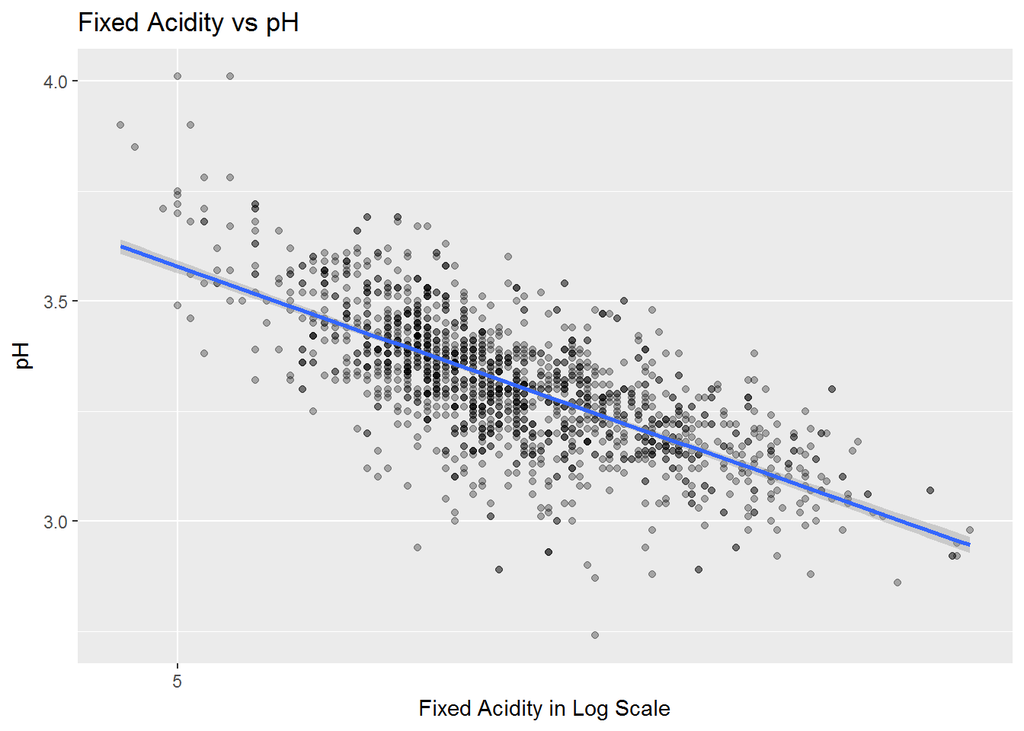

### 12. Analysing PH vs Volatile Acidity

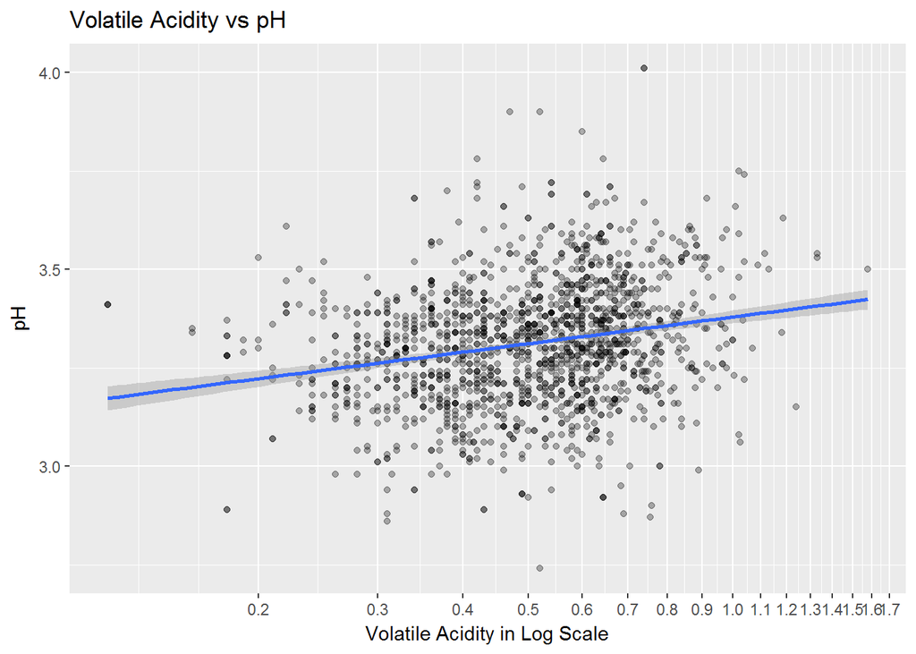

### 12. Analysing PH vs Citric Acid

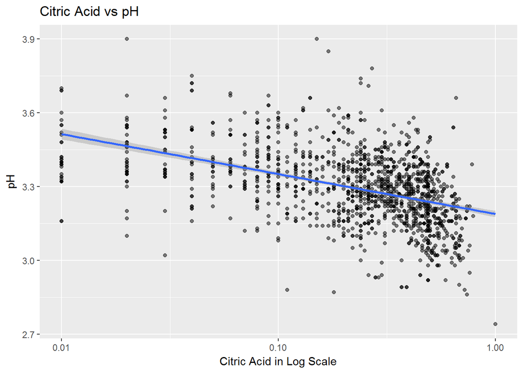

These three plots brings more confusion into play. Previously we found out that for Volatile Acid, pH has a positive correlation. But we know acidity has a negative correlation with pH. so there might be a possibility of data biasing and incorrect reading over here.

### 13. Analysing Quality vs Sulphates

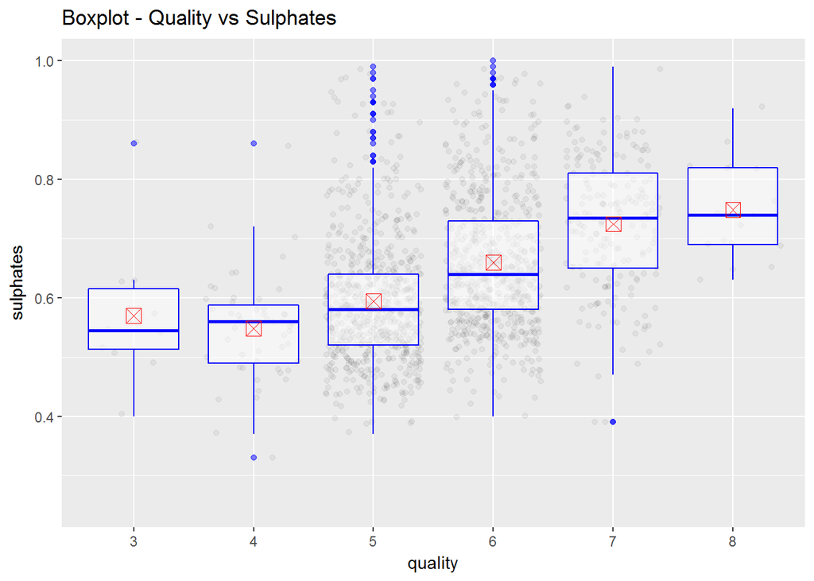

Even though we see many outliers in the ‘Average’ quality wine, it seems that sulphates has a good correlation with wine quality. Better wines have a stronger concentration of Sulphates.

### 14. Analysing Quality vs Alcohol

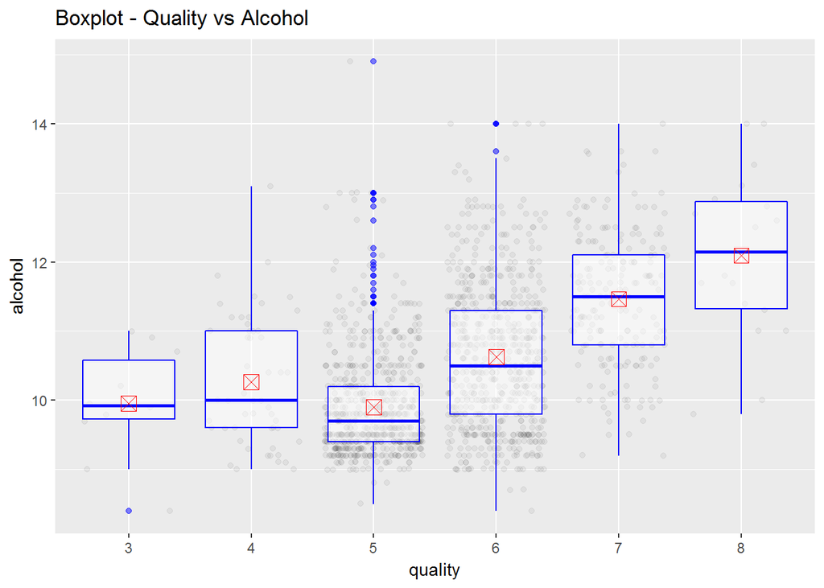

It is evident that better wines have higher Alcohol content in it. But still due to presence of large number of outliers here, it might be possible that alcohol alone does not contribute to wine quality. We need to build a simple linear model and try to get the statistics and R-squared value to get some more lights into it.

### 15. Regressing Alcohol with Quality

```
##
## Call:
## lm(formula = as.numeric(quality) ~ alcohol, data = redWineQuality)
##
## Residuals:
##     Min      1Q  Median      3Q     Max
## -2.8442 -0.4112 -0.1690  0.5166  2.5888
##
## Coefficients:
##             Estimate Std. Error t value Pr(>|t|)
## (Intercept) -0.12503    0.17471  -0.716    0.474
## alcohol      0.36084    0.01668  21.639   <2e-16 ***
## ---
## Signif. codes:  0 '***' 0.001 '**' 0.01 '*' 0.05 '.' 0.1 ' ' 1
##
## Residual standard error: 0.7104 on 1597 degrees of freedom
## Multiple R-squared:  0.2267, Adjusted R-squared:  0.2263
## F-statistic: 468.3 on 1 and 1597 DF,  p-value: < 2.2e-16
```

Based on the value of R squared, we see that Alcohol alone contributes to only about 22% of the Wine quality. To build a good fit model further, we need to find the other variables which are contributing to wine quality as well.

So now we will put a correlation test against each variable to the quality of the wine.

```
##        fixed.acidity     volatile.acidity          citric.acid
##           0.12405165          -0.39055778           0.22637251
## log10.residual.sugar      log10.chlordies  free.sulfur.dioxide
##           0.02353331          -0.17613996          -0.05065606
## total.sulfur.dioxide              density                   pH
##          -0.18510029          -0.17491923          -0.05773139
##      log10.sulphates              alcohol
##           0.30864193           0.47616632
```

### ——————————————————————————————————————

### ——————————————————————————————————————

## 6. Analysis of Bivariate Plots

### 1. Our Objective

Our aim is to find out how the quality of red wine varies with different ingredients. Hence we have tried to regress each and every independent variable to the ‘Quality’ parameter. This would help us further in Multivariate analysis as we got the idea about the parameters we need to take into consideration further.

### 2. Inference

1. Good quality Wine seems to have a high Alcohol percentage as well as higher concentration of Citric Acid. But from our linear regresion model we can see only 22% of total wine quality is contributed by Alcohol. This may be due to the biased reading that we got or it may be due to other fators coming into play.
2. Fixed Acidity seems to have almost no effect on quality.
3. Volatile Acidity seems to have a negative correlation with the quality.
4. Even though weakly correlated, but lower percent of Chloride seems to produce better quality wines.
5. Good wines also have properties like lower densities and tends to be more acidic.
6. Residual sugar almost has no effect on the wine quality.

### ——————————————————————————————————————

### ——————————————————————————————————————

## 7. Multivariate Plots

We have already concluded that Alcohol percentage forms a strong factor in wine quality. But again it only pertains to 20%-22% of the total quality. So there must be some other factors which decides the wine quality. This is where Multivariate Plot is coming into play. We need to decide other factors keeping alcohol fixed. We will then infer how other variables are coming into play.

### 1. Analysing Alcohol vs Density

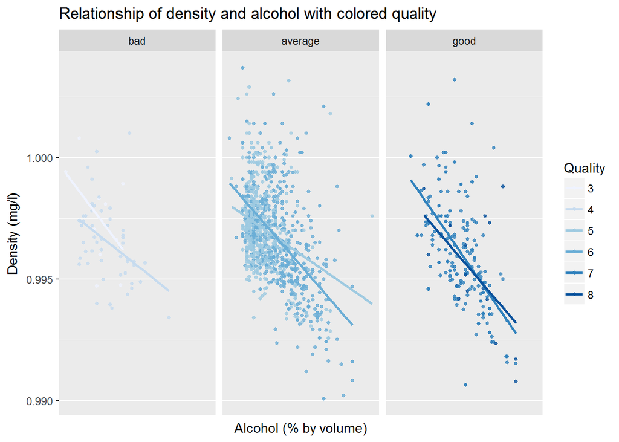

With constant Alcohol, Density does not seem to play a prominet role in changing the quality of the alcohol. So our previous suspicion must be true that the correlation we were seeing of density with quality was due to alcohol percent.

### 2. Analysing Alcohol vs Sulphates

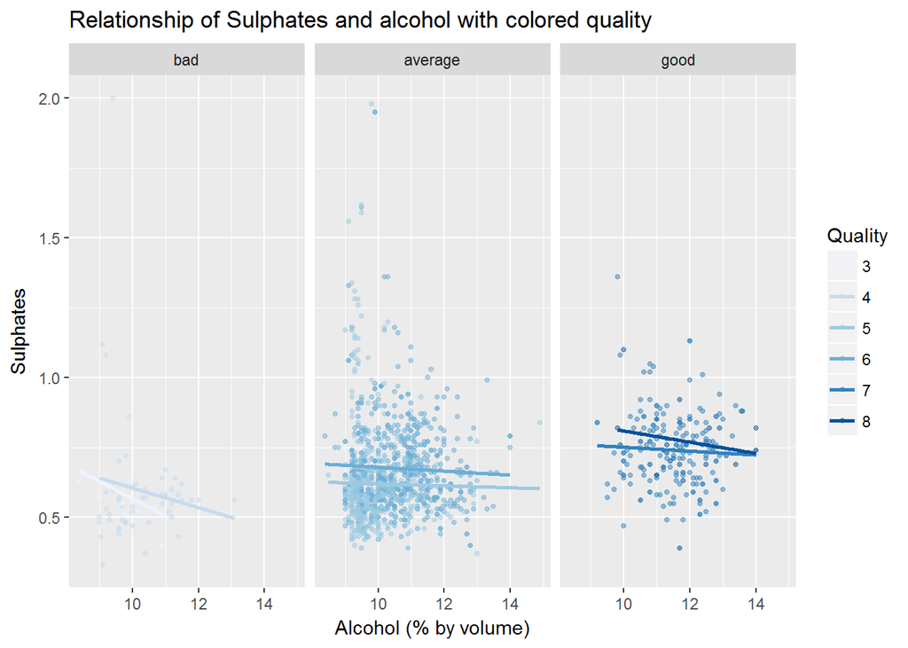

It looks like Wines with higher alcohol content produce better wine if they have higher level of Sulphates.

### 3. Analysing Alcohol vs Volatile Acidity

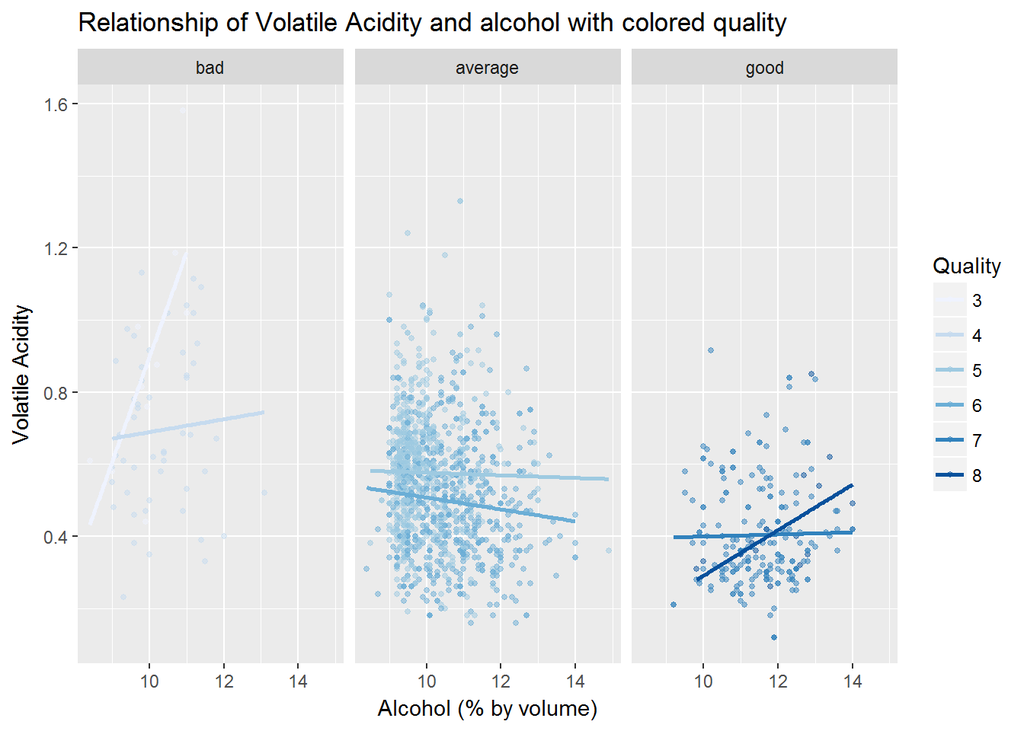

From the above graph it is evident that less concentration of volatile acid and higher concentration of alcohol seems to produce better wines.

### 4. Analysing Alcohol vs PH

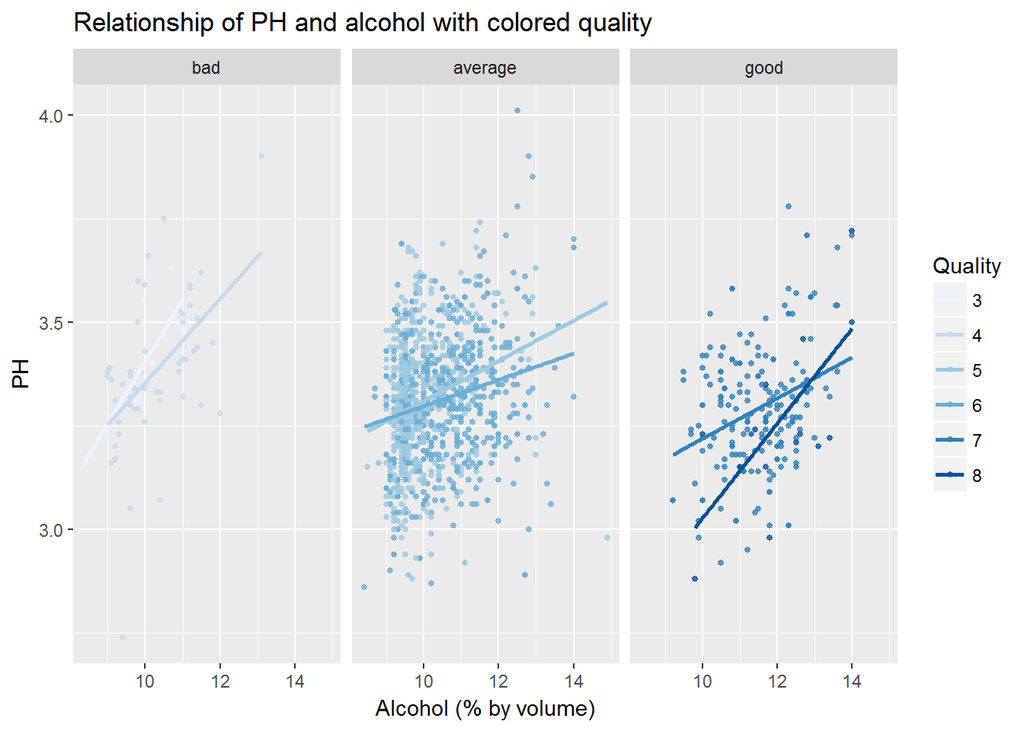

Low pH and high Alcohol percentage seems to produce better wines.